# Network Visualization

03/30/2020

## Edges and Vertics

Generally think of graphs as having edges and vertices

- Vertices can be thought of as objects
- Edges can be thought of as relations between objects
  - May be directed or undirected

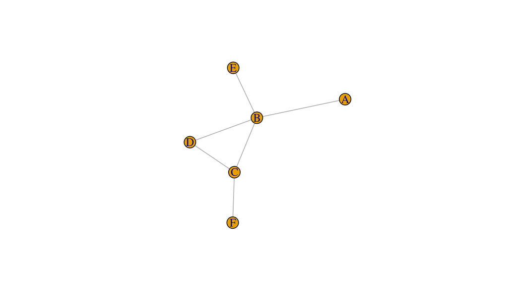

*Social Network Analysis* has recently become a subject of considerable interest

- Social media
- Disease transmission
- Biological networks
- Terrorist networks

There is a nice tutorial on network visualization in R at http://kateto.net/network-visualization by Rutgers’s own Katherine Ognyanova. There is also an effort to make a tidy version of network data, called [ggnet2](https://briatte.github.io/ggnet/)

## igraph and statnet

- `igraph` is a library of graph visualization functions for Python and R; the R package is simply called `igraph`
- `statnet` is a suite of packages for network analysis (e.g., not just visualization)

## Basics

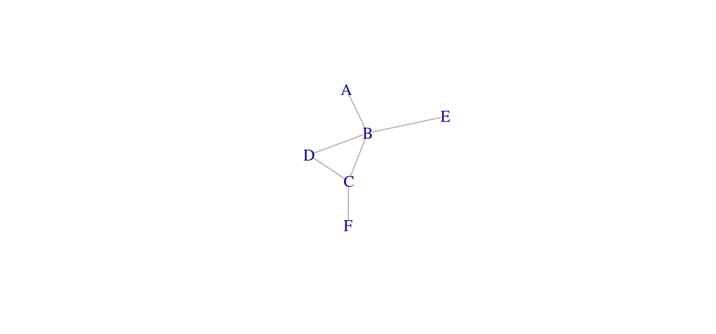

Networks can be represented in multiple ways, including by matrices \[\left( \begin{matrix} 0 & 1 & 0 & 0 & 0 & 0\\ 1 & 0 & 1 & 1 & 1 & 0\\ 0 & 1 & 0 & 1 & 0 & 1\\ 0 & 1 & 1 & 0 & 0 & 0\\ 0 & 1 & 0 & 0 & 0 & 0\\ 0 & 0 & 1 & 0 & 0 & 0 \end{matrix} \right) \]

or as a matrix of edge pairs

```
##   from to
## 1    A  B
## 2    B  C
## 3    B  E
## 4    B  D
## 5    C  D
## 6    C  F
```

## `igraph` representation

`igraph` had its own representation of graphs. For a small graph, one can import it via `graph_from_literal()`

```r
library(igraph)
(ex_g <- graph_from_literal(
  A -- B,
  B -- C,
  B -- E,
  B -- D,
  D -- C,
  C -- F)
)
```

```
## IGRAPH f6c72e7 UN-- 6 6 --
## + attr: name (v/c)
## + edges from f6c72e7 (vertex names):
## [1] A--B B--C B--E B--D C--D C--F
```

There are other `graph_from_*()` functions, of which `graph_from_edgelist()` and `graph_from_adjacency_matrix()` are particularly useful.

`as_adjacency_matrix()`, `as_edgelist()` and so on will generate the various data structures.

```r
as_adjacency_matrix(ex_g, sparse = FALSE)
```

```
##   A B C E D F
## A 0 1 0 0 0 0
## B 1 0 1 1 1 0
## C 0 1 0 0 1 1
## E 0 1 0 0 0 0
## D 0 1 1 0 0 0
## F 0 0 1 0 0 0
```

## Other graph formats

`igraph` allows import and export from a number of common formats, using the `read_graph()` and `write_graph()` functions.

## Attributes

Graphs, edges, and vertices all have attributes

```r
library(igraphdata)
data(kite)
graph_attr(kite)
```

```
## $name
## [1] "Krackhardt's kite"
##
## $layout
##       [,1] [,2]
##  [1,]    1    4
##  [2,]    1    2
##  [3,]    2    5
##  [4,]    2    3
##  [5,]    2    1
##  [6,]    3    4
##  [7,]    3    2
##  [8,]    4    3
##  [9,]    5    3
## [10,]    6    3
##
## $Citation
## [1] "Assessing the Political Landscape: Structure, Cognition, and Power in Organizations. David Krackhardt. Admin. Sci. Quart. 35, 342-369, 1990."
##
## $Author
## [1] "David Krackhardt"
##
## $URL
## [1] "http://www.orgnet.com/sna.html"
```

```r
vertex_attr_names(kite)
```

```
## [1] "label"     "Firstname" "name"
```

```r
vertex_attr(kite, "Firstname")
```

```
##  [1] "Andre"    "Beverly"  "Carol"    "Diane"    "Ed"       "Fernando"
##  [7] "Garth"    "Heather"  "Ike"      "Jane"
```

```r
edge_attr_names(kite)
```

```
## character(0)
```

There are various tools to add or delete vertices or edges, to look at neighborhoods, and so on.

## Visualization

Since plotting is done using base R and the generic plot function, you will need to look at `?plot.igraph` to get help.

For small graphs, the defaults will work well

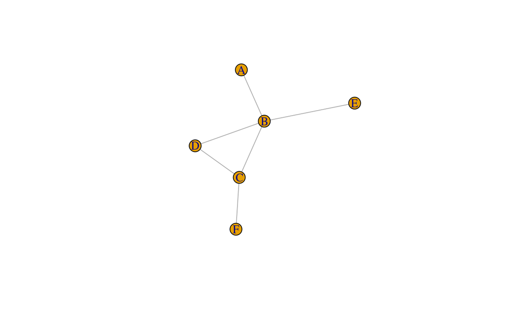

```r
plot(ex_g)
```

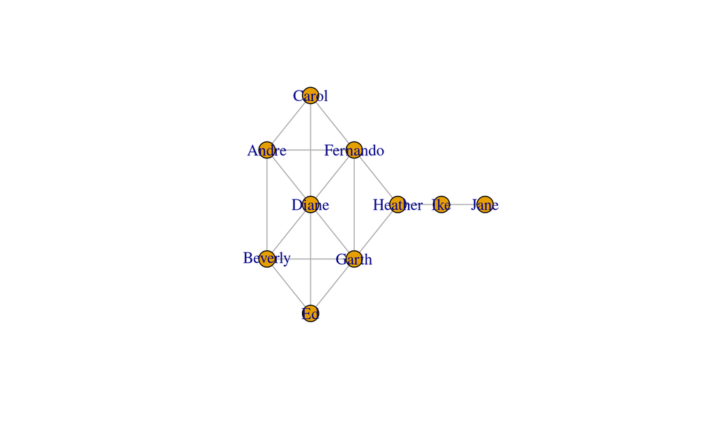

```r
plot(kite, vertex.label = vertex_attr(kite, "Firstname"))
```

## In class exercise

Run the following code and experiment with different plot layouts

```
install.packages("igraphinshiny") # Or install from Tools menu
library(igraphinshiny)
plotDemo()
```

## An extended example

[figure not shown]

Inspired by http://varianceexplained.org/r/love-actually-network/

## Movie trailer at https://youtu.be/1dYv5u6v55Y

## From screenplay to incidence matrix

The screenplay can be found [here](http://www.imsdb.com/scripts/Pride-and-Prejudice.html), but I saved it as a text file.

```r
library(stringr)
raw.pnp <- readLines("pride_and_prejudice_screenplay_2005.txt")

(lines <- data_frame(raw = raw.pnp) %>% filter(raw != ""))
```

```
## # A tibble: 5,568 x 1
##    raw
##    <chr>
##  1 "PRIDE AND PREJUDICE"
##  2 "                         "
##  3 "                                Written by"
##  4 "                             Deborah Moggach"
##  5 "                         "
##  6 "                         "
##  7 "          1 INT. NETHERFIELD - HERTFORDSHIRE - DAY. I"
##  8 "          A vast mansion is coming to life. Maids pull dustsheets"
##  9 "          off furniture; servants open shutters. Sunshine spills"
## 10 "          into the great rooms of Netherfield. outside, a glimpse"
## # … with 5,558 more rows
```

Consider

```r
lines[45:52,]
```

```
## # A tibble: 8 x 1
##   raw
##   <chr>
## 1 "          any choice in the matter..."
## 2 "                         "
## 3 "                         "
## 4 "                         "
## 5 "                         "
## 6 "          2."
## 7 "          3 INT. LONGBOURN - CONTINUOUS."
## 8 "          As Elizabeth walks through the hallway, we hear the sound"
```

```r
lines <- data_frame(raw = raw.pnp) %>% filter(raw != "") %>%
  filter(raw != raw.pnp[3], # blanks
    !str_detect(raw, " {10}[0-9]+\\."), !str_detect(raw, "CONT'D"))
```

```r
lines[32:41,]
```

```
## # A tibble: 10 x 1
##    raw
##    <chr>
##  1 "          and father, Mr and Mrs Bennet."
##  2 "                         MRS BENNET"
##  3 "          My dear Mr Bennet, have you heard that"
##  4 "          Netherfield Park is let at last?"
##  5 "          We follow Elizabeth into the house, but still overhear"
##  6 "          her parents' conversation."
##  7 "          Do you not want to know who has taken it?"
##  8 "                         MR BENNET"
##  9 "          As you wish to tell me, I doubt I have"
## 10 "          any choice in the matter..."
```

```r
lines <- data_frame(raw = raw.pnp) %>%
    filter(raw != "", !str_detect(raw, " {10}[0-9]+\\."),
      raw != raw.pnp[3], !str_detect(raw, "CONT'D")) %>%
    mutate(is_scene = str_detect(raw, " {10}[0-9]+ [A-Z]{2,}"),
           scene = cumsum(is_scene))

with(lines, head(data.frame(line = substr(str_trim(raw), 1, 10), scene)))
```

```
##         line scene
## 1 PRIDE AND      0
## 2 Written by     0
## 3 Deborah Mo     0
## 4 1 INT. NET     1
## 5 A vast man     1
## 6 off furnit     1
```

Finally, strip away everything but the full caps lines

```r
lines <- data_frame(raw = raw.pnp) %>%
    filter(raw != "", !str_detect(raw, " {10}[0-9]+\\."),
      raw != raw.pnp[3], !str_detect(raw, "CONT'D")) %>%
    mutate(is_scene = str_detect(raw, " {10}[0-9]+ [A-Z]{2,}"),
           scene = cumsum(is_scene)) %>%
    filter(!is_scene, scene > 0) %>%
    filter(str_detect(raw, " {25}[A-Z .1-9]{2,}")) %>%
    select(-is_scene)

lines <- rename(lines, character = raw)
lines <- mutate(lines, character = str_trim(character))
```

```r
sort(unique(lines$character))
```

```
##  [1] "ACQUAINTANCE\""   "ASKS:"            "BAMBOOZLED)"      "BINGLEY"
##  [5] "BINGLEY)"         "BUTLER"           "CAROLINE BINGLEY" "CHARLOTTE"
##  [9] "CHILD-"           "COLLINS"          "COURSE -"         "CUT TO"
## [13] "CUT TO;"          "CUT TO:"          "DANCING PARTNER"  "DARCY"
## [17] "DARCY -"          "DARCY ELIZABETH"  "DOCTOR"           "DOOR)"
## [21] "ELISABETH"        "ELIZABETH"        "ELIZABETH'"       "FITZWILLIAM"
## [25] "FOOTMAN"          "GEORGIANA"        "GEORGIANA)"       "HER HUSBAND"
## [29] "IMPERTINENCE --"  "IS"               "JANE"             "KITTY"
## [33] "LADY CATHERINE"   "LIZZIE"           "LIZZIE_"          "LYDIA"
## [37] "LYDIA -"          "MAID"             "MARY"             "MISS BINGLEY"
## [41] "MR BENNET"        "MR BENNET'"       "MR BINGLEY"       "MR COLLINS"
## [45] "MR DARCY"         "MR GARDINER"      "MR KENNET"        "MR WICKHAM"
## [49] "MRS BENNET"       "MRS GARDINER"     "MRS HILL"         "MRS REYNOLDS"
## [53] "NICELY-"          "P C"              "PARTNER ME_"      "PEMBERLEY -"
## [57] "PLAYING)"         "POSTMASTER"       "RECOVERING)"      "REYNOLDS SPEECH:"
## [61] "ROOM:"            "SERVANT"          "SIR WILLIAM"      "STEWARD -"
## [65] "SUBJECT-"         "TITLE:"           "WICKHAM"          "WOMAN"
```

```r
drop_characters <- c("ACQUAINTANCE\"", "ASKS:", "BAMBOOZLED)", "CHILD-",  "COURSE -", "CUT TO", "CUT TO;", "CUT TO:", "DANCING PARTNER",  "DOCTOR", "DOOR)",  "IMPERTINENCE --", "IS",  "NICELY-", "P C", "PARTNER ME_", "PEMBERLEY -", "PLAYING)", "RECOVERING)", "REYNOLDS SPEECH:", "ROOM:",  "STEWARD -", "SUBJECT-", "TITLE:")

lines <- lines %>% filter(!(character %in% drop_characters))
sort(unique(lines$character))
```

```
##  [1] "BINGLEY"          "BINGLEY)"         "BUTLER"           "CAROLINE BINGLEY"
##  [5] "CHARLOTTE"        "COLLINS"          "DARCY"            "DARCY -"
##  [9] "DARCY ELIZABETH"  "ELISABETH"        "ELIZABETH"        "ELIZABETH'"
## [13] "FITZWILLIAM"      "FOOTMAN"          "GEORGIANA"        "GEORGIANA)"
## [17] "HER HUSBAND"      "JANE"             "KITTY"            "LADY CATHERINE"
## [21] "LIZZIE"           "LIZZIE_"          "LYDIA"            "LYDIA -"
## [25] "MAID"             "MARY"             "MISS BINGLEY"     "MR BENNET"
## [29] "MR BENNET'"       "MR BINGLEY"       "MR COLLINS"       "MR DARCY"
## [33] "MR GARDINER"      "MR KENNET"        "MR WICKHAM"       "MRS BENNET"
## [37] "MRS GARDINER"     "MRS HILL"         "MRS REYNOLDS"     "POSTMASTER"
## [41] "SERVANT"          "SIR WILLIAM"      "WICKHAM"          "WOMAN"
```

```r
lines$character <- lines$character %>%
  str_replace_all("[-']", "") %>% str_replace_all("_", "") %>%
  str_replace_all("\\)", "") %>% str_trim()
```

```r
sort(unique(lines$character))
```

```
##  [1] "BINGLEY"          "BUTLER"           "CAROLINE BINGLEY" "CHARLOTTE"
##  [5] "COLLINS"          "DARCY"            "DARCY ELIZABETH"  "ELISABETH"
##  [9] "ELIZABETH"        "FITZWILLIAM"      "FOOTMAN"          "GEORGIANA"
## [13] "HER HUSBAND"      "JANE"             "KITTY"            "LADY CATHERINE"
## [17] "LIZZIE"           "LYDIA"            "MAID"             "MARY"
## [21] "MISS BINGLEY"     "MR BENNET"        "MR BINGLEY"       "MR COLLINS"
## [25] "MR DARCY"         "MR GARDINER"      "MR KENNET"        "MR WICKHAM"
## [29] "MRS BENNET"       "MRS GARDINER"     "MRS HILL"         "MRS REYNOLDS"
## [33] "POSTMASTER"       "SERVANT"          "SIR WILLIAM"      "WICKHAM"
## [37] "WOMAN"
```

```r
lines$character[lines$character == "MR DARCY"] <- "DARCY"
lines$character[lines$character == "MR BINGLEY"] <- "BINGLEY"
lines$character[lines$character == "ELISABETH"] <- "ELIZABETH"
lines$character[lines$character == "MISS BINGLEY"] <- "CAROLINE BINGLEY"
lines$character[lines$character == "LIZZIE"] <- "ELIZABETH"
lines$character[lines$character == "COLLINS"] <- "MR COLLINS"
lines$character[lines$character == "MR WICKHAM"] <- "WICKHAM"
lines$character[lines$character == "MR KENNET"] <- "MR BENNET"
lines <- lines %>% filter(character != "DARCY ELIZABETH")
```

The data is now almost ready to work with

```r
by_character_scene <- lines %>% count(scene, character)
by_character_scene
```

```
## # A tibble: 314 x 3
##    scene character      n
##    <int> <chr>      <int>
##  1     2 MR BENNET      1
##  2     2 MRS BENNET     1
##  3     3 JANE           1
##  4     3 KITTY          1
##  5     3 LYDIA          2
##  6     3 MR BENNET      2
##  7     3 MRS BENNET     2
##  8     4 MRS BENNET     1
##  9     5 ELIZABETH      1
## 10     5 JANE           1
## # … with 304 more rows
```

```r
character_scene_matrix <-
   table(unique(lines[, c("character", "scene")]))
head(character_scene_matrix)
```

```
##                   scene
## character          2 3 4 5 6 7 8 11 14 16 18 19 20 21 22 24 28 29 30 31 33 34
##   BINGLEY          0 0 0 0 1 0 0  0  0  0  0  1  1  1  0  1  0  1  1  0  0  0
##   BUTLER           0 0 0 0 0 0 0  0  0  0  0  0  0  0  0  0  0  1  0  0  0  0
##   CAROLINE BINGLEY 0 0 0 0 1 0 0  0  0  0  1  0  0  1  0  1  0  1  1  0  0  0
##   CHARLOTTE        0 0 0 0 1 0 0  0  0  0  0  0  0  0  0  0  0  0  0  0  0  0
##   DARCY            0 0 0 0 1 0 0  0  0  0  1  0  0  0  0  1  0  1  1  0  0  0
##   ELIZABETH        0 0 0 1 1 1 1  0  1  1  1  0  1  0  0  1  1  1  1  0  1  0
##                   scene
## character          35 36 37 38 39 40 41 42 43 44 45 46 48 49 50 51 52 55 56 57
##   BINGLEY           0  0  0  0  0  0  0  1  0  0  0  1  0  0  0  0  0  0  0  0
##   BUTLER            0  0  0  0  0  0  0  0  0  0  0  0  0  0  0  0  0  0  0  0
##   CAROLINE BINGLEY  0  0  0  0  0  0  0  0  0  0  0  1  0  0  0  0  0  0  0  0
##   CHARLOTTE         1  0  0  0  0  0  0  0  1  0  0  1  0  0  0  0  0  0  0  1
##   DARCY             0  0  0  0  0  0  0  0  0  0  0  1  0  0  0  0  0  0  0  0
##   ELIZABETH         1  0  1  0  1  1  1  1  1  1  1  1  1  1  0  1  1  1  1  1
##                   scene
## character          58 60 61 62 63 64 65 66 67 68 69 70 71 72 73 75 76 77 78 79
##   BINGLEY           0  0  0  0  0  0  0  0  0  0  0  0  0  0  0  0  0  0  0  0
##   BUTLER            0  0  0  0  0  0  0  0  0  0  0  0  0  0  0  0  0  0  0  0
##   CAROLINE BINGLEY  0  0  0  0  0  0  0  0  0  0  0  0  0  0  0  0  0  0  0  0
##   CHARLOTTE         0  0  1  1  0  0  1  0  1  1  0  0  1  1  0  1  0  0  0  0
##   DARCY             0  0  0  0  0  0  1  1  1  1  0  1  0  0  1  0  0  0  0  0
##   ELIZABETH         1  0  0  1  0  0  1  1  1  1  1  1  1  1  0  1  1  1  1  1
##                   scene
## character          80 83 84 85 86 87 88 89 90 91 92 93 94 95 97 98 99 100 101
##   BINGLEY           0  0  0  0  0  0  0  0  0  0  0  0  0  0  0  0  0   0   0
##   BUTLER            0  0  0  0  0  0  0  0  0  0  0  0  0  0  0  0  0   0   0
##   CAROLINE BINGLEY  0  0  0  0  0  0  0  0  0  0  1  0  0  0  0  0  0   0   0
##   CHARLOTTE         0  0  0  0  0  0  0  0  0  0  0  0  0  0  0  0  0   0   0
##   DARCY             0  0  0  0  0  0  0  1  1  0  1  1  0  1  0  0  0   0   0
##   ELIZABETH         1  1  1  0  0  0  1  1  0  1  1  1  1  1  1  0  0   1   1
##                   scene
## character          102 104 105 106 107 108 109 110 111 113 114 115 116 117 120
##   BINGLEY            0   0   0   0   0   0   0   0   0   1   1   1   0   0   0
##   BUTLER             0   0   0   0   0   0   1   0   0   0   0   0   0   0   0
##   CAROLINE BINGLEY   0   0   0   0   0   0   0   0   0   0   0   0   0   0   0
##   CHARLOTTE          0   0   0   0   0   0   0   0   0   0   0   0   0   0   0
##   DARCY              0   0   0   0   0   0   1   0   0   1   1   0   0   0   0
##   ELIZABETH          1   1   1   0   1   1   0   1   0   1   0   1   0   0   0
##                   scene
## character          121 122 123 127 128 129 131 132
##   BINGLEY            0   0   0   0   0   0   0   0
##   BUTLER             0   0   0   0   0   0   0   0
##   CAROLINE BINGLEY   0   0   0   0   0   0   0   0
##   CHARLOTTE          0   0   0   0   0   0   0   0
##   DARCY              0   0   0   1   0   0   0   1
##   ELIZABETH          1   1   1   1   1   1   1   1
```

```r
character_adjacency <- character_scene_matrix %*% t(character_scene_matrix)
head(character_adjacency)
```

```
##                   character
## character          BINGLEY BUTLER CAROLINE BINGLEY CHARLOTTE DARCY ELIZABETH
##   BINGLEY               12      1                6         2     7         9
##   BUTLER                 1      2                1         0     2         1
##   CAROLINE BINGLEY       6      1                8         2     7         7
##   CHARLOTTE              2      0                2        13     5        12
##   DARCY                  7      2                7         5    22        18
##   ELIZABETH              9      1                7        12    18        74
##                   character
## character          FITZWILLIAM FOOTMAN GEORGIANA HER HUSBAND JANE KITTY
##   BINGLEY                    0       0         0           0    7     5
##   BUTLER                     0       0         0           0    0     1
##   CAROLINE BINGLEY           0       1         1           0    3     2
##   CHARLOTTE                  2       0         0           0    2     2
##   DARCY                      2       1         1           0    4     3
##   ELIZABETH                  3       1         1           1   19    16
##                   character
## character          LADY CATHERINE LYDIA MAID MARY MR BENNET MR COLLINS
##   BINGLEY                       0     3    0    2         2          1
##   BUTLER                        0     1    0    1         0          0
##   CAROLINE BINGLEY              0     2    0    2         2          1
##   CHARLOTTE                     2     2    0    2         2          5
##   DARCY                         3     2    0    2         2          2
##   ELIZABETH                     5    15    1    8        19          6
##                   character
## character          MR GARDINER MRS BENNET MRS GARDINER MRS HILL MRS REYNOLDS
##   BINGLEY                    0          5            0        0            0
##   BUTLER                     0          1            0        0            0
##   CAROLINE BINGLEY           0          3            0        0            0
##   CHARLOTTE                  0          2            0        0            0
##   DARCY                      1          4            1        0            0
##   ELIZABETH                  6         22            7        1            1
##                   character
## character          POSTMASTER SERVANT SIR WILLIAM WICKHAM WOMAN
##   BINGLEY                   0       0           1       1     0
##   BUTLER                    0       0           0       0     0
##   CAROLINE BINGLEY          0       0           1       0     0
##   CHARLOTTE                 0       0           2       1     0
##   DARCY                     0       0           1       0     0
##   ELIZABETH                 1       1           2       8     1
```

## Clustering

Not all network visualizations are plots of edges and vertices. For example, we could try clustering. https://en.wikipedia.org/wiki/Dendrogram

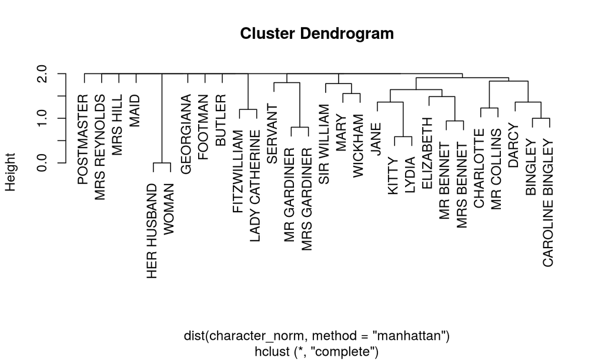

```r
character_norm <- character_scene_matrix / rowSums(character_scene_matrix)

character_hclust <- hclust(dist(character_norm, method = "manhattan"))

plot(character_hclust)
```

## Heatmap

Or a heatmap

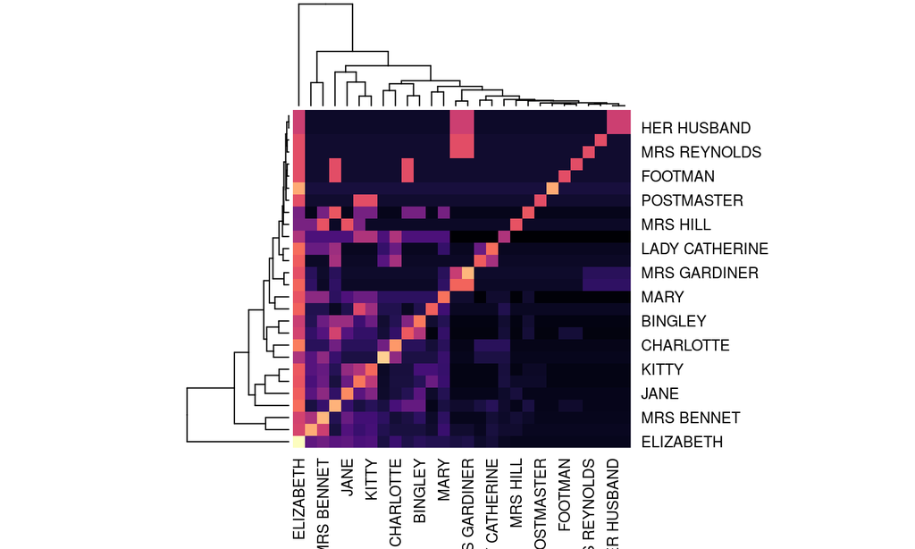

```r
library(viridis) # for colors
heatmap(character_adjacency, col = viridis(n = 256, alpha = 1, begin = 0, end = 1, option = "A"))
```

Or maybe a timeline of scenes

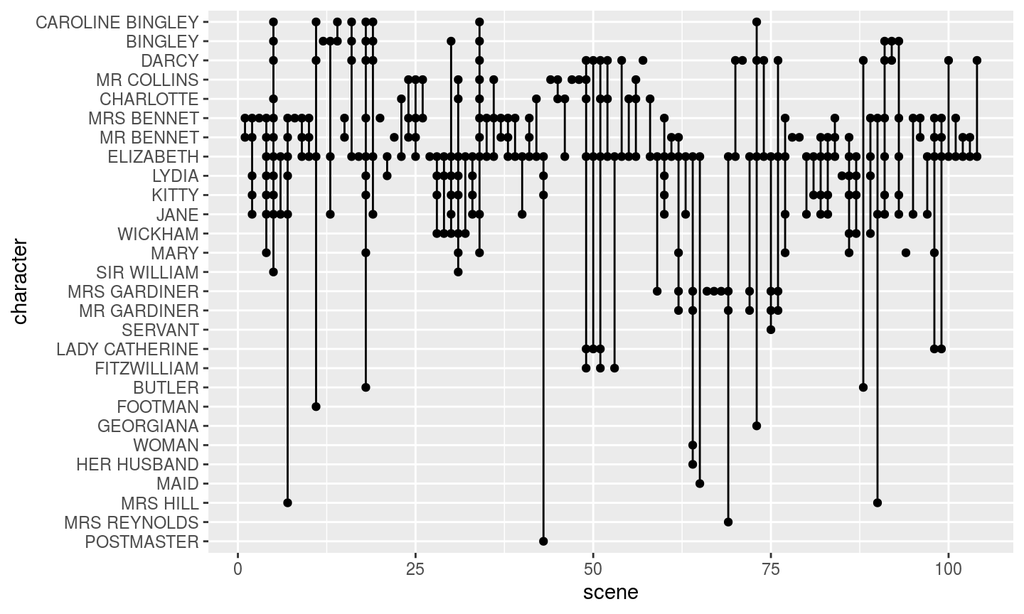

```r
character_ordering <- character_hclust$labels[character_hclust$order]

scenes <- by_character_scene %>%
    filter(n() > 1) %>%        # scenes with > 1 character
    ungroup() %>%
    mutate(scene = as.numeric(factor(scene)),
           character = factor(character, levels = character_ordering))

ggplot(scenes, aes(scene, character)) +
    geom_point() +
    geom_path(aes(group = scene))
```

## And now some vertices-and-edges

```r
character_graph <- graph.adjacency(character_adjacency,
      weighted = TRUE, mode = "undirected", diag = FALSE)
character_graph2 <- delete_vertices(character_graph,
      V(character_graph)[diag(character_adjacency) <= 10])
## You can extract information about vertices with V() and
## edges with E()
```

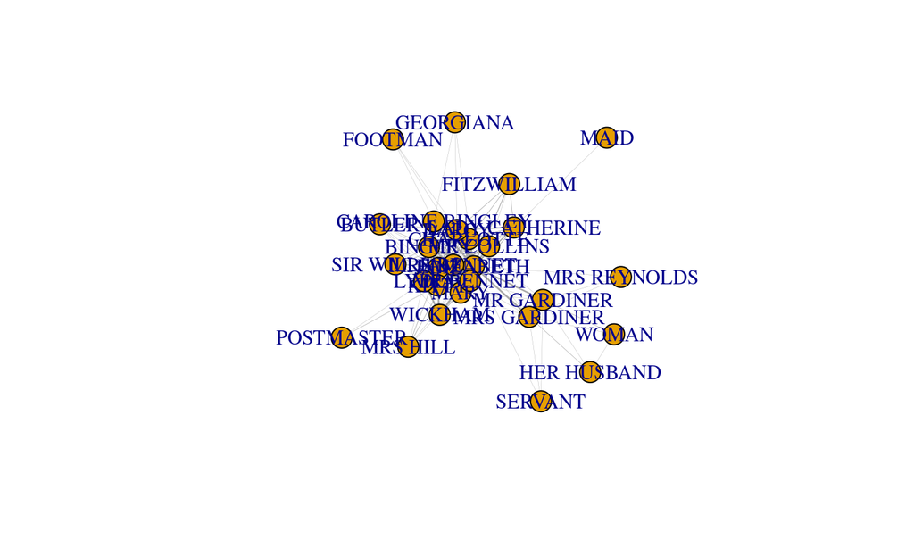

```r
plot(character_graph, edge.width = E(character_graph)$weight/5,
     layout = layout_with_fr)
```

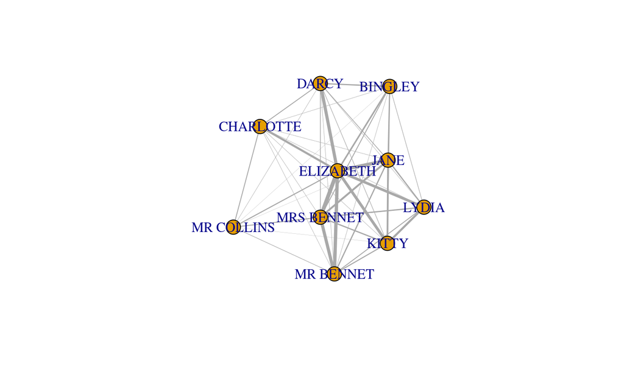

```r
plot(character_graph2, edge.width = E(character_graph2)$weight/5,
     layout = layout_with_fr)
```